# MIDTERM : Analytics Technology

In this assignment you are going to have several tasks:

1. Import several CSV files:
   - Physicians
   - Scripts (files 1 – 10)
   - Zip Codes
2. Create provider summary and org summary tables
3. There are 10 analysis questions each requiring a TABLE and at least 1 CHART (Barplot) To get the results you’ll likely need to break things up into steps and perform various steps including:
   - Query to filter data
   - Merge to join data
   - N-largest / N-smallest (top N, Bottom N)
   - Concat to append datasets together
   - agg (sum, count, mean, min, max)
   - create barplots using seaborn
   - Rename columns using df.column = [“col1”,”col2”,…]
4. Devise 5 of your own analysis questions answered with tables and visualizations
5. Extra Credit

```python
# --------------------------------
import warnings
warnings.filterwarnings('ignore')
# --------------------------------

import pandas as pd
import numpy as np
import matplotlib.pyplot  as plt
import seaborn as sns

%matplotlib inline
```

## Import Data

You are provided several files you'll need to import the files and append (concat) them into a single table after you import.

```
example = pd.concat(["phys1","phys2","phys3"],axis=0)
example.head()
```

**Providers:**

https://raw.githubusercontent.com/MonkeyWrenchGang/MGTPython/main/module_5/mid-term/scnctn_physicians_1.csv https://raw.githubusercontent.com/MonkeyWrenchGang/MGTPython/main/module_5/mid-term/scnctn_physicians_2.csv https://raw.githubusercontent.com/MonkeyWrenchGang/MGTPython/main/module_5/mid-term/scnctn_physicians_3.csv

**Prescriptions:**

https://raw.githubusercontent.com/MonkeyWrenchGang/MGTPython/main/module_5/mid-term/scnctn_scripts_1.csv https://raw.githubusercontent.com/MonkeyWrenchGang/MGTPython/main/module_5/mid-term/scnctn_scripts_2.csv https://raw.githubusercontent.com/MonkeyWrenchGang/MGTPython/main/module_5/mid-term/scnctn_scripts_3.csv https://raw.githubusercontent.com/MonkeyWrenchGang/MGTPython/main/module_5/mid-term/scnctn_scripts_4.csv https://raw.githubusercontent.com/MonkeyWrenchGang/MGTPython/main/module_5/mid-term/scnctn_scripts_5.csv https://raw.githubusercontent.com/MonkeyWrenchGang/MGTPython/main/module_5/mid-term/scnctn_scripts_6.csv https://raw.githubusercontent.com/MonkeyWrenchGang/MGTPython/main/module_5/mid-term/scnctn_scripts_7.csv https://raw.githubusercontent.com/MonkeyWrenchGang/MGTPython/main/module_5/mid-term/scnctn_scripts_8.csv https://raw.githubusercontent.com/MonkeyWrenchGang/MGTPython/main/module_5/mid-term/scnctn_scripts_9.csv https://raw.githubusercontent.com/MonkeyWrenchGang/MGTPython/main/module_5/mid-term/scnctn_scripts_10.csv

**Zips:** "https://raw.githubusercontent.com/MonkeyWrenchGang/MGTPython/main/module_5/mid-term/zipcode_usa.csv"

NOTE: zips is delimited by `;`

```
zips = pd.read_csv("https://raw.githubusercontent.com/MonkeyWrenchGang/MGTPython/main/module_5/mid-term/zipcode_usa.csv",sep=";")
zips.head()
```

My advice is to clean up the column names using:

```
zips.columns = ( zips.columns
    .str.strip()
    .str.lower()
    .str.replace(' ', '_')
    .str.replace('-', '_')
    .str.replace('(', '')
    .str.replace(')', '')
    .str.replace('?', '')
    .str.replace('\'', '') # notice the backslash \ this is an escape character
)
print(zips.columns)
zips.head()
```

```python
#Providers
phys1=pd.read_csv('https://raw.githubusercontent.com/MonkeyWrenchGang/MGTPython/main/module_5/mid-term/scnctn_physicians_1.csv')
phys2=pd.read_csv('https://raw.githubusercontent.com/MonkeyWrenchGang/MGTPython/main/module_5/mid-term/scnctn_physicians_2.csv')
phys3=pd.read_csv('https://raw.githubusercontent.com/MonkeyWrenchGang/MGTPython/main/module_5/mid-term/scnctn_physicians_3.csv')
```

```python
physicians= pd.concat([phys1,phys2,phys3],axis=0)
physicians.head()
```

|  | Rndrng_NPI | Rndrng_Prvdr_Last_Org_Name | Rndrng_Prvdr_First_Name | Rndrng_Prvdr_MI | Rndrng_Prvdr_Crdntls | Rndrng_Prvdr_Gndr | Rndrng_Prvdr_Ent_Cd | Rndrng_Prvdr_St1 | Rndrng_Prvdr_St2 | Rndrng_Prvdr_City | ... | Bene_CC_Dprssn_Pct | Bene_CC_Dbts_Pct | Bene_CC_Hyplpdma_Pct | Bene_CC_Hyprtnsn_Pct | Bene_CC_IHD_Pct | Bene_CC_Opo_Pct | Bene_CC_RAOA_Pct | Bene_CC_Sz_Pct | Bene_CC_Strok_Pct | Bene_Avg_Risk_Scre |
| --- | --- | --- | --- | --- | --- | --- | --- | --- | --- | --- | --- | --- | --- | --- | --- | --- | --- | --- | --- | --- | --- |
| 0 | 1003000720 | Hernandez | Otniel | NaN | DNP | M | I | 3163 Gammon Ln Ste 422 | NaN | Clemmons | ... | 0.27 | 0.28 | 0.46 | 0.62 | 0.22 | 0.09 | 0.38 | 0.06 | NaN | 1.3417 |
| 1 | 1003000936 | Stellingworth | Mark | A | MD | M | I | 701 Medical Park Dr Ste 301 | NaN | Hartsville | ... | 0.25 | 0.45 | 0.75 | 0.75 | 0.64 | 0.07 | 0.53 | 0.04 | 0.13 | 1.8890 |
| 2 | 1003002254 | Walgreen Co. | NaN | NaN | NaN | NaN | O | 5104 Bobby Hicks Hwy | NaN | Gray | ... | 0.18 | 0.18 | 0.52 | 0.55 | 0.25 | NaN | 0.36 | 0.00 | NaN | 0.8218 |
| 3 | 1003002841 | Choudhary | Saher | K | M.D. | F | I | 109 Physicians Dr Ste C | NaN | Greer | ... | 0.41 | 0.42 | 0.75 | 0.75 | 0.49 | 0.12 | 0.42 | NaN | 0.74 | 1.8582 |
| 4 | 1003006172 | Quezada | Nestor | NaN | MD | M | I | 4539 Hedgemore Dr | Ste 100 | Charlotte | ... | 0.43 | 0.57 | 0.71 | 0.75 | 0.47 | 0.11 | 0.52 | 0.06 | 0.14 | 3.2293 |

5 rows × 73 columns

```python
physicians.shape
```

```
(84037, 73)
```

```python
#clean column names
physicians.columns = ( physicians.columns
    .str.strip()
    .str.lower()
    .str.replace(' ', '_')
    .str.replace('-', '_')
    .str.replace('(', '')
    .str.replace(')', '')
    .str.replace('?', '')
    .str.replace('\'', '')
)
print(physicians.columns)
physicians.head()
```

```
Index(['rndrng_npi', 'rndrng_prvdr_last_org_name', 'rndrng_prvdr_first_name',
       'rndrng_prvdr_mi', 'rndrng_prvdr_crdntls', 'rndrng_prvdr_gndr',
       'rndrng_prvdr_ent_cd', 'rndrng_prvdr_st1', 'rndrng_prvdr_st2',
       'rndrng_prvdr_city', 'rndrng_prvdr_state_abrvtn',
       'rndrng_prvdr_state_fips', 'rndrng_prvdr_zip5', 'rndrng_prvdr_ruca',
       'rndrng_prvdr_ruca_desc', 'rndrng_prvdr_cntry', 'rndrng_prvdr_type',
       'rndrng_prvdr_mdcr_prtcptg_ind', 'tot_hcpcs_cds', 'tot_benes',
       'tot_srvcs', 'tot_sbmtd_chrg', 'tot_mdcr_alowd_amt',
       'tot_mdcr_pymt_amt', 'tot_mdcr_stdzd_amt', 'drug_sprsn_ind',
       'drug_tot_hcpcs_cds', 'drug_tot_benes', 'drug_tot_srvcs',
       'drug_sbmtd_chrg', 'drug_mdcr_alowd_amt', 'drug_mdcr_pymt_amt',
       'drug_mdcr_stdzd_amt', 'med_sprsn_ind', 'med_tot_hcpcs_cds',
       'med_tot_benes', 'med_tot_srvcs', 'med_sbmtd_chrg',
       'med_mdcr_alowd_amt', 'med_mdcr_pymt_amt', 'med_mdcr_stdzd_amt',
       'bene_avg_age', 'bene_age_lt_65_cnt', 'bene_age_65_74_cnt',
       'bene_age_75_84_cnt', 'bene_age_gt_84_cnt', 'bene_feml_cnt',
       'bene_male_cnt', 'bene_race_wht_cnt', 'bene_race_black_cnt',
       'bene_race_api_cnt', 'bene_race_hspnc_cnt', 'bene_race_natind_cnt',
       'bene_race_othr_cnt', 'bene_dual_cnt', 'bene_ndual_cnt',
       'bene_cc_af_pct', 'bene_cc_alzhmr_pct', 'bene_cc_asthma_pct',
       'bene_cc_cncr_pct', 'bene_cc_chf_pct', 'bene_cc_ckd_pct',
       'bene_cc_copd_pct', 'bene_cc_dprssn_pct', 'bene_cc_dbts_pct',
       'bene_cc_hyplpdma_pct', 'bene_cc_hyprtnsn_pct', 'bene_cc_ihd_pct',
       'bene_cc_opo_pct', 'bene_cc_raoa_pct', 'bene_cc_sz_pct',
       'bene_cc_strok_pct', 'bene_avg_risk_scre'],
      dtype='object')
```

|  | rndrng_npi | rndrng_prvdr_last_org_name | rndrng_prvdr_first_name | rndrng_prvdr_mi | rndrng_prvdr_crdntls | rndrng_prvdr_gndr | rndrng_prvdr_ent_cd | rndrng_prvdr_st1 | rndrng_prvdr_st2 | rndrng_prvdr_city | ... | bene_cc_dprssn_pct | bene_cc_dbts_pct | bene_cc_hyplpdma_pct | bene_cc_hyprtnsn_pct | bene_cc_ihd_pct | bene_cc_opo_pct | bene_cc_raoa_pct | bene_cc_sz_pct | bene_cc_strok_pct | bene_avg_risk_scre |
| --- | --- | --- | --- | --- | --- | --- | --- | --- | --- | --- | --- | --- | --- | --- | --- | --- | --- | --- | --- | --- | --- |
| 0 | 1003000720 | Hernandez | Otniel | NaN | DNP | M | I | 3163 Gammon Ln Ste 422 | NaN | Clemmons | ... | 0.27 | 0.28 | 0.46 | 0.62 | 0.22 | 0.09 | 0.38 | 0.06 | NaN | 1.3417 |
| 1 | 1003000936 | Stellingworth | Mark | A | MD | M | I | 701 Medical Park Dr Ste 301 | NaN | Hartsville | ... | 0.25 | 0.45 | 0.75 | 0.75 | 0.64 | 0.07 | 0.53 | 0.04 | 0.13 | 1.8890 |
| 2 | 1003002254 | Walgreen Co. | NaN | NaN | NaN | NaN | O | 5104 Bobby Hicks Hwy | NaN | Gray | ... | 0.18 | 0.18 | 0.52 | 0.55 | 0.25 | NaN | 0.36 | 0.00 | NaN | 0.8218 |
| 3 | 1003002841 | Choudhary | Saher | K | M.D. | F | I | 109 Physicians Dr Ste C | NaN | Greer | ... | 0.41 | 0.42 | 0.75 | 0.75 | 0.49 | 0.12 | 0.42 | NaN | 0.74 | 1.8582 |
| 4 | 1003006172 | Quezada | Nestor | NaN | MD | M | I | 4539 Hedgemore Dr | Ste 100 | Charlotte | ... | 0.43 | 0.57 | 0.71 | 0.75 | 0.47 | 0.11 | 0.52 | 0.06 | 0.14 | 3.2293 |

5 rows × 73 columns

```python
#Prescriptions
script1= pd.read_csv('https://raw.githubusercontent.com/MonkeyWrenchGang/MGTPython/main/module_5/mid-term/scnctn_scripts_1.csv')
script2= pd.read_csv('https://raw.githubusercontent.com/MonkeyWrenchGang/MGTPython/main/module_5/mid-term/scnctn_scripts_2.csv')
script3= pd.read_csv('https://raw.githubusercontent.com/MonkeyWrenchGang/MGTPython/main/module_5/mid-term/scnctn_scripts_3.csv')
script4= pd.read_csv('https://raw.githubusercontent.com/MonkeyWrenchGang/MGTPython/main/module_5/mid-term/scnctn_scripts_4.csv')
script5= pd.read_csv('https://raw.githubusercontent.com/MonkeyWrenchGang/MGTPython/main/module_5/mid-term/scnctn_scripts_5.csv')
script6= pd.read_csv('https://raw.githubusercontent.com/MonkeyWrenchGang/MGTPython/main/module_5/mid-term/scnctn_scripts_6.csv')
script7= pd.read_csv('https://raw.githubusercontent.com/MonkeyWrenchGang/MGTPython/main/module_5/mid-term/scnctn_scripts_7.csv')
script8= pd.read_csv('https://raw.githubusercontent.com/MonkeyWrenchGang/MGTPython/main/module_5/mid-term/scnctn_scripts_8.csv')
script9= pd.read_csv('https://raw.githubusercontent.com/MonkeyWrenchGang/MGTPython/main/module_5/mid-term/scnctn_scripts_9.csv')
script10=pd.read_csv('https://raw.githubusercontent.com/MonkeyWrenchGang/MGTPython/main/module_5/mid-term/scnctn_scripts_10.csv')
```

```python
prescriptions = pd.concat([script1, script2, script3, script4, script5, script6,script7, script8, script9, script10],axis=0)
prescriptions.head()
```

|  | ...1 | prscrbr_npi | brnd_name | gnrc_name | tot_clms | tot_30day_fills | tot_day_suply | tot_drug_cst | tot_benes | is_opiate |
| --- | --- | --- | --- | --- | --- | --- | --- | --- | --- | --- |
| 0 | 0.0 | 1003000720 | Albuterol Sulfate Hfa | Albuterol Sulfate | 14 | 14.0 | 337 | 657.01 | 14.0 | No |
| 1 | 1.0 | 1003000720 | Amoxicillin-Clavulanate Potass | Amoxicillin/Potassium Clav | 34 | 34.0 | 328 | 412.06 | 34.0 | No |
| 2 | 2.0 | 1003000720 | Azithromycin | Azithromycin | 12 | 12.0 | 52 | 87.21 | 12.0 | No |
| 3 | 3.0 | 1003000720 | Cephalexin | Cephalexin | 25 | 25.0 | 211 | 144.27 | 25.0 | No |
| 4 | 4.0 | 1003000720 | Clindamycin Hcl | Clindamycin Hcl | 11 | 11.0 | 87 | 111.93 | 11.0 | No |

```python
#clean column names
prescriptions.columns = ( prescriptions.columns
    .str.strip()
    .str.lower()
    .str.replace(' ', '_')
    .str.replace('-', '_')
    .str.replace('(', '')
    .str.replace(')', '')
    .str.replace('?', '')
    .str.replace('\'', '')
)
print(prescriptions.columns)
prescriptions.head()
```

```
Index(['...1', 'prscrbr_npi', 'brnd_name', 'gnrc_name', 'tot_clms',
       'tot_30day_fills', 'tot_day_suply', 'tot_drug_cst', 'tot_benes',
       'is_opiate'],
      dtype='object')
```

|  | ...1 | prscrbr_npi | brnd_name | gnrc_name | tot_clms | tot_30day_fills | tot_day_suply | tot_drug_cst | tot_benes | is_opiate |
| --- | --- | --- | --- | --- | --- | --- | --- | --- | --- | --- |
| 0 | 0.0 | 1003000720 | Albuterol Sulfate Hfa | Albuterol Sulfate | 14 | 14.0 | 337 | 657.01 | 14.0 | No |
| 1 | 1.0 | 1003000720 | Amoxicillin-Clavulanate Potass | Amoxicillin/Potassium Clav | 34 | 34.0 | 328 | 412.06 | 34.0 | No |
| 2 | 2.0 | 1003000720 | Azithromycin | Azithromycin | 12 | 12.0 | 52 | 87.21 | 12.0 | No |
| 3 | 3.0 | 1003000720 | Cephalexin | Cephalexin | 25 | 25.0 | 211 | 144.27 | 25.0 | No |
| 4 | 4.0 | 1003000720 | Clindamycin Hcl | Clindamycin Hcl | 11 | 11.0 | 87 | 111.93 | 11.0 | No |

```python
zips = pd.read_csv("https://raw.githubusercontent.com/MonkeyWrenchGang/MGTPython/main/module_5/mid-term/zipcode_usa.csv",sep=";")
zips.head()
```

|  | Zip Code | Official USPS city name | Official USPS State Code | Official State Name | ZCTA | ZCTA parent | Population | Density | Primary Official County Code | Primary Official County Name | County Weights | Official County Name | Official County Code | Imprecise | Military | Timezone | Geo Point |
| --- | --- | --- | --- | --- | --- | --- | --- | --- | --- | --- | --- | --- | --- | --- | --- | --- | --- |
| 0 | 90005 | Los Angeles | CA | California | True | NaN | 39732.0 | 14151.8 | 6037 | Los Angeles | {"06037": "100"} | Los Angeles | 6037 | False | False | America/Los_Angeles | 34.05912, -118.30654 |
| 1 | 90006 | Los Angeles | CA | California | True | NaN | 59576.0 | 11981.7 | 6037 | Los Angeles | {"06037": "100"} | Los Angeles | 6037 | False | False | America/Los_Angeles | 34.04801, -118.29418 |
| 2 | 90008 | Los Angeles | CA | California | True | NaN | 31754.0 | 3337.9 | 6037 | Los Angeles | {"06037": "100"} | Los Angeles | 6037 | False | False | America/Los_Angeles | 34.00956, -118.34706 |
| 3 | 90040 | Los Angeles | CA | California | True | NaN | 12328.0 | 852.8 | 6037 | Los Angeles | {"06037": "100"} | Los Angeles | 6037 | False | False | America/Los_Angeles | 33.99353, -118.14907 |
| 4 | 90045 | Los Angeles | CA | California | True | NaN | 40567.0 | 1459.6 | 6037 | Los Angeles | {"06037": "100"} | Los Angeles | 6037 | False | False | America/Los_Angeles | 33.95297, -118.40014 |

```python
#clean column names
zips.columns = ( zips.columns
    .str.strip()
    .str.lower()
    .str.replace(' ', '_')
    .str.replace('-', '_')
    .str.replace('(', '')
    .str.replace(')', '')
    .str.replace('?', '')
    .str.replace('\'', '')
)
print(zips.columns)
zips.head()
```

```
Index(['zip_code', 'official_usps_city_name', 'official_usps_state_code',
       'official_state_name', 'zcta', 'zcta_parent', 'population', 'density',
       'primary_official_county_code', 'primary_official_county_name',
       'county_weights', 'official_county_name', 'official_county_code',
       'imprecise', 'military', 'timezone', 'geo_point'],
      dtype='object')
```

|  | zip_code | official_usps_city_name | official_usps_state_code | official_state_name | zcta | zcta_parent | population | density | primary_official_county_code | primary_official_county_name | county_weights | official_county_name | official_county_code | imprecise | military | timezone | geo_point |
| --- | --- | --- | --- | --- | --- | --- | --- | --- | --- | --- | --- | --- | --- | --- | --- | --- | --- |
| 0 | 90005 | Los Angeles | CA | California | True | NaN | 39732.0 | 14151.8 | 6037 | Los Angeles | {"06037": "100"} | Los Angeles | 6037 | False | False | America/Los_Angeles | 34.05912, -118.30654 |
| 1 | 90006 | Los Angeles | CA | California | True | NaN | 59576.0 | 11981.7 | 6037 | Los Angeles | {"06037": "100"} | Los Angeles | 6037 | False | False | America/Los_Angeles | 34.04801, -118.29418 |
| 2 | 90008 | Los Angeles | CA | California | True | NaN | 31754.0 | 3337.9 | 6037 | Los Angeles | {"06037": "100"} | Los Angeles | 6037 | False | False | America/Los_Angeles | 34.00956, -118.34706 |
| 3 | 90040 | Los Angeles | CA | California | True | NaN | 12328.0 | 852.8 | 6037 | Los Angeles | {"06037": "100"} | Los Angeles | 6037 | False | False | America/Los_Angeles | 33.99353, -118.14907 |
| 4 | 90045 | Los Angeles | CA | California | True | NaN | 40567.0 | 1459.6 | 6037 | Los Angeles | {"06037": "100"} | Los Angeles | 6037 | False | False | America/Los_Angeles | 33.95297, -118.40014 |

## TASK 2 – STRUCTURE

### TASK 2A - Create Physician Summary, Create Org Summary

### TASK 2b - Filter “Rndrng_Prvdr_Ent_Cd” == “O”

```python
#2A Physician Summary
physician_summary=physicians
```

```python
physician_summary=physician_summary[physician_summary["rndrng_prvdr_ent_cd"]=='I']
```

```python
#inner join
physician_summary=pd.merge(physician_summary, zips, left_on='rndrng_prvdr_zip5', right_on='zip_code', how='inner')
```

```python
#new column
physician_summary['provider_name']= (
physician_summary['rndrng_npi'].astype(str)+ ": "+
physician_summary['rndrng_prvdr_first_name'] + " " +
physician_summary['rndrng_prvdr_last_org_name']
)
```

```python
physician_summary.shape
```

```
(72658, 91)
```

```python
physician_summary.head(2)
```

|  | rndrng_npi | rndrng_prvdr_last_org_name | rndrng_prvdr_first_name | rndrng_prvdr_mi | rndrng_prvdr_crdntls | rndrng_prvdr_gndr | rndrng_prvdr_ent_cd | rndrng_prvdr_st1 | rndrng_prvdr_st2 | rndrng_prvdr_city | ... | primary_official_county_code | primary_official_county_name | county_weights | official_county_name | official_county_code | imprecise | military | timezone | geo_point | provider_name |
| --- | --- | --- | --- | --- | --- | --- | --- | --- | --- | --- | --- | --- | --- | --- | --- | --- | --- | --- | --- | --- | --- |
| 0 | 1003000720 | Hernandez | Otniel | NaN | DNP | M | I | 3163 Gammon Ln Ste 422 | NaN | Clemmons | ... | 37067 | Forsyth | {"37067": "80.04", "37057": "19.96"} | Forsyth,Davidson | 37067,37057 | False | False | America/New_York | 36.0041, -80.37582 | 1003000720: Otniel Hernandez |
| 1 | 1013204148 | Merritt | Carrie | H | PA | F | I | 105 Stadium Oaks Dr | NaN | Clemmons | ... | 37067 | Forsyth | {"37067": "80.04", "37057": "19.96"} | Forsyth,Davidson | 37067,37057 | False | False | America/New_York | 36.0041, -80.37582 | 1013204148: Carrie Merritt |

2 rows × 91 columns

```python
#2B Org summary
org_summary=physicians
org_summary=org_summary[org_summary["rndrng_prvdr_ent_cd"]=='O']
org_summary= pd.merge(org_summary, zips, left_on ='rndrng_prvdr_zip5', right_on='zip_code', how='inner')
```

```python
#new column
org_summary['org_name']= (
org_summary['rndrng_npi'].astype(str)+ ": "+
org_summary['rndrng_prvdr_last_org_name'] + " " +
org_summary['official_usps_state_code']
)
```

```python
org_summary.shape
```

```
(4279, 91)
```

```python
org_summary.head(2)
```

|  | rndrng_npi | rndrng_prvdr_last_org_name | rndrng_prvdr_first_name | rndrng_prvdr_mi | rndrng_prvdr_crdntls | rndrng_prvdr_gndr | rndrng_prvdr_ent_cd | rndrng_prvdr_st1 | rndrng_prvdr_st2 | rndrng_prvdr_city | ... | primary_official_county_code | primary_official_county_name | county_weights | official_county_name | official_county_code | imprecise | military | timezone | geo_point | org_name |
| --- | --- | --- | --- | --- | --- | --- | --- | --- | --- | --- | --- | --- | --- | --- | --- | --- | --- | --- | --- | --- | --- |
| 0 | 1003002254 | Walgreen Co. | NaN | NaN | NaN | NaN | O | 5104 Bobby Hicks Hwy | NaN | Gray | ... | 47179 | Washington | {"47179": "100"} | Washington | 47179 | False | False | America/New_York | 36.39958, -82.45219 | 1003002254: Walgreen Co. TN |
| 1 | 1033624853 | East Tennessee Healthcare Holdings Inc | NaN | NaN | NaN | NaN | O | 203 Gray Commons Cir Ste 110 | NaN | Gray | ... | 47179 | Washington | {"47179": "100"} | Washington | 47179 | False | False | America/New_York | 36.39958, -82.45219 | 1033624853: East Tennessee Healthcare Holdings... |

2 rows × 91 columns

# TASK 3 - ANALYSIS

There are 10 analysis tasks, requiring you to build a table (RESnn) and at least one bar-chart. For each analysis add a Markdown Cell at the top denoting which analysis step this is. i've added an example for Analysis result 1

## RES01: “TOP 10 MEDICARE PROVIDERS BY TOT_MDCR_PYMT_AMT”

```python
grouped_medicare_providers=physician_summary.groupby('provider_name')['tot_mdcr_pymt_amt'].sum()
top10_providers=grouped_medicare_providers.nlargest(10)
```

```python
df_top10=top10_providers.reset_index()
df_top10.columns=['provider_name', 'tot_mdcr_pymt_amt']
df_top10
```

|  | provider_name | tot_mdcr_pymt_amt |
| --- | --- | --- |
| 0 | 1851320691: Bradley Somer | 14030052.64 |
| 1 | 1366683823: Wanda Lowery | 11462667.60 |
| 2 | 1750541553: Shil Patel | 10526851.61 |
| 3 | 1023018728: Ross Kerns | 8945222.23 |
| 4 | 1801103643: Syed Sameer Nasir | 8347614.58 |
| 5 | 1679529473: David Portnoy | 8169092.45 |
| 6 | 1639179708: Mitchell Martin | 8148045.67 |
| 7 | 1932209855: Robert Lavey | 8060160.20 |
| 8 | 1982670147: John Doster | 7796761.71 |
| 9 | 1619947876: Daniel Ibach | 7643785.10 |

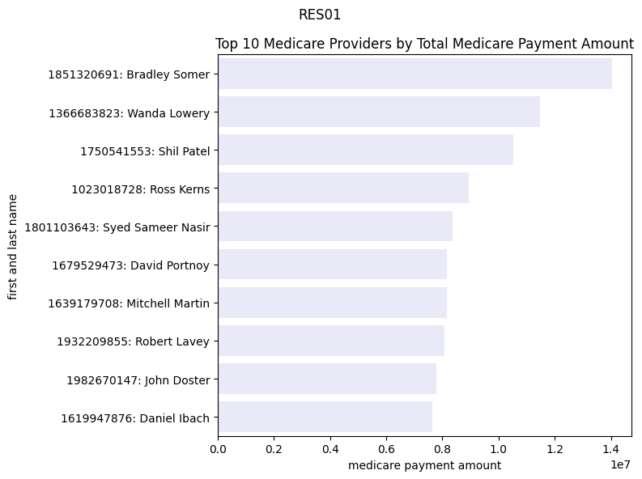

```python
plt.figure(figsize=(8, 6))
sns.barplot(x='tot_mdcr_pymt_amt', y='provider_name', data=df_top10, color='lavender')
plt.xlabel('medicare payment amount')
plt.ylabel('first and last name')
plt.title('Top 10 Medicare Providers by Total Medicare Payment Amount')
plt.suptitle('RES01')
plt.tight_layout()
plt.show()
```

## RES02: TITLE “TOP 10 MEDICARE ORGANIZATIONS BY TOT_MDCR_PYMT_AMT”

```python
grouped_medicare_orgs=org_summary.groupby('org_name')['tot_mdcr_pymt_amt'].sum()
top10_orgs =grouped_medicare_orgs.nlargest(10)
```

```python
df_top10_orgs=top10_orgs.reset_index()
df_top10_orgs.columns=['org_name', 'tot_mdcr_pymt_amt']
df_top10_orgs
```

|  | org_name | tot_mdcr_pymt_amt |
| --- | --- | --- |
| 0 | 1538144910: Laboratory Corporation Of America ... | 2.346708e+08 |
| 1 | 1174009245: Vikor Scientific, Llc SC | 4.219851e+07 |
| 2 | 1699782722: Aegis Sciences Corporation TN | 3.306643e+07 |
| 3 | 1134538713: Mako Medical Laboratories, Llc NC | 3.128753e+07 |
| 4 | 1235186800: Pathgroup Labs, Llc TN | 2.179726e+07 |
| 5 | 1548370745: Memphis Pathology Laboratory TN | 2.015901e+07 |
| 6 | 1750368700: Laboratory Corporation Of America ... | 1.964342e+07 |
| 7 | 1124417357: Aegis Sciences Corporation TN | 1.693110e+07 |
| 8 | 1487212551: Quest Diagnostics Clinical Laborat... | 1.586682e+07 |
| 9 | 1508215922: Foundation Medicine, Inc. NC | 1.564063e+07 |

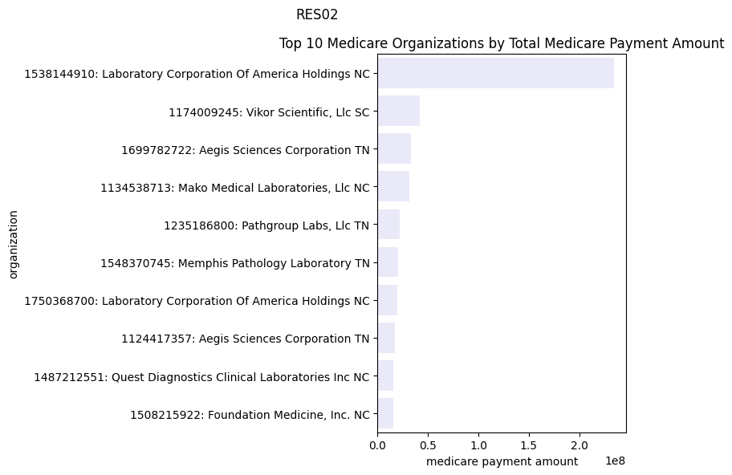

```python
plt.figure(figsize=(8, 6))
sns.barplot(x='tot_mdcr_pymt_amt', y='org_name', data=df_top10_orgs, color='lavender')
plt.xlabel('medicare payment amount')
plt.ylabel('organization')
plt.title('Top 10 Medicare Organizations by Total Medicare Payment Amount')
plt.suptitle('RES02')
plt.tight_layout()
plt.show()
```

## RES03: TITLE “NURSE PRACTITIONERS BY STATE”

```python
df_np=physician_summary[physician_summary['rndrng_prvdr_type']=='Nurse Practitioner']
grouped_np=df_np.groupby('rndrng_prvdr_state_abrvtn')['rndrng_prvdr_type'].count().sort_values(ascending=False)
df_grouped_np= grouped_np.reset_index()
df_grouped_np.columns= ['rndrng_prvdr_state_abrvtn','rndrng_prvdr_type' ]
df_grouped_np
```

|  | rndrng_prvdr_state_abrvtn | rndrng_prvdr_type |
| --- | --- | --- |
| 0 | TN | 5314 |
| 1 | NC | 4997 |
| 2 | SC | 2552 |

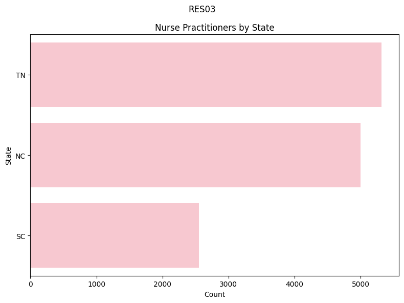

```python
plt.figure(figsize=(8, 6))
sns.barplot(x='rndrng_prvdr_type', y='rndrng_prvdr_state_abrvtn', data=df_grouped_np, color='pink')
plt.xlabel('Count')
plt.ylabel('State')
plt.title('Nurse Practitioners by State')
plt.suptitle('RES03')
plt.tight_layout()
plt.show()
```

## RES04: TITLE “ORGANIZATION TOTAL SPENDING BY STATE

```python
grouped_org_spending=org_summary.groupby('rndrng_prvdr_state_abrvtn')['tot_mdcr_pymt_amt'].sum().sort_values(ascending=False)
grouped_org_spending= grouped_org_spending.reset_index()
grouped_org_spending.columns=['state', 'tot_mdcr_pymt_amt']
grouped_org_spending
```

|  | state | tot_mdcr_pymt_amt |
| --- | --- | --- |
| 0 | NC | 6.411749e+08 |
| 1 | TN | 4.086610e+08 |
| 2 | SC | 2.890731e+08 |

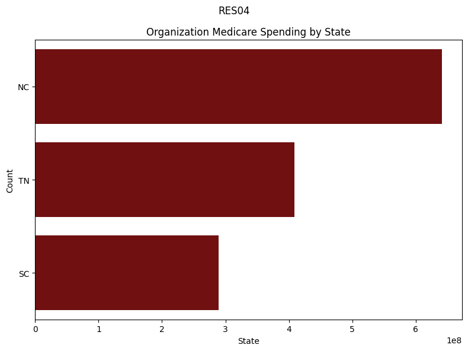

```python
plt.figure(figsize=(8, 6))
sns.barplot(x='tot_mdcr_pymt_amt', y='state', data=grouped_org_spending, color= 'maroon')
plt.xlabel('State')
plt.ylabel('Count')
plt.title('Organization Medicare Spending by State')
plt.suptitle('RES04')
plt.tight_layout()
plt.show()
```

## RES05: TITLE “TOP 5 ORG SPENDING BY STATE AND SPECIALTY”

```python
res05= (org_summary
        .groupby(['rndrng_prvdr_state_abrvtn', 'rndrng_prvdr_type'])
        .agg({'tot_mdcr_pymt_amt':['sum']})
        .reset_index()
        )

res05.columns= ['state', 'provider_type', 'sum']
df_res05=res05.sort_values(by='sum', ascending=False).groupby('state').head(5).sort_values(by='state', ascending=False)
df_res05
```

|  | state | provider_type | sum |
| --- | --- | --- | --- |
| 30 | TN | Clinical Laboratory | 1.287518e+08 |
| 26 | TN | Ambulance Service Provider | 1.287374e+08 |
| 27 | TN | Ambulatory Surgical Center | 1.084014e+08 |
| 32 | TN | Mass Immunizer Roster Biller | 1.084933e+07 |
| 28 | TN | Centralized Flu | 7.241423e+06 |
| 14 | SC | Ambulance Service Provider | 1.093598e+08 |
| 15 | SC | Ambulatory Surgical Center | 7.856921e+07 |
| 18 | SC | Clinical Laboratory | 7.181143e+07 |
| 21 | SC | Mass Immunizer Roster Biller | 1.038471e+07 |
| 19 | SC | Independent Diagnostic Testing Facility (IDTF) | 9.208320e+06 |
| 5 | NC | Clinical Laboratory | 3.572441e+08 |
| 1 | NC | Ambulance Service Provider | 1.445288e+08 |
| 2 | NC | Ambulatory Surgical Center | 7.816452e+07 |
| 8 | NC | Mass Immunizer Roster Biller | 1.600421e+07 |
| 10 | NC | Pharmacy | 1.343819e+07 |

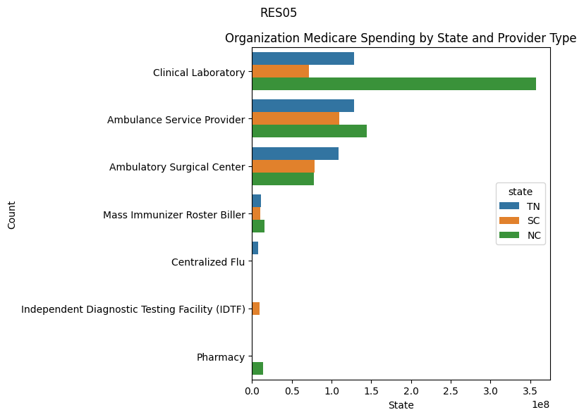

```python
plt.figure(figsize=(8, 6))
sns.barplot(x='sum', y='provider_type', hue='state', data=df_res05)
plt.xlabel('State')
plt.ylabel('Count')
plt.title('Organization Medicare Spending by State and Provider Type')
plt.suptitle('RES05')
plt.tight_layout()
plt.show()
```

## RES06: TITLE “TOP 5 PROVIDERs by SPENDING SPECIALTY”

```python
res06= physician_summary.groupby('rndrng_prvdr_type')['tot_mdcr_pymt_amt'].sum().sort_values(ascending=False)
df_res06=res06.reset_index().nlargest(5,'tot_mdcr_pymt_amt')
df_res06
```

|  | rndrng_prvdr_type | tot_mdcr_pymt_amt |
| --- | --- | --- |
| 0 | Ophthalmology | 5.050825e+08 |
| 1 | Internal Medicine | 4.851399e+08 |
| 2 | Hematology-Oncology | 4.503906e+08 |
| 3 | Nurse Practitioner | 4.433272e+08 |
| 4 | Family Practice | 3.812270e+08 |

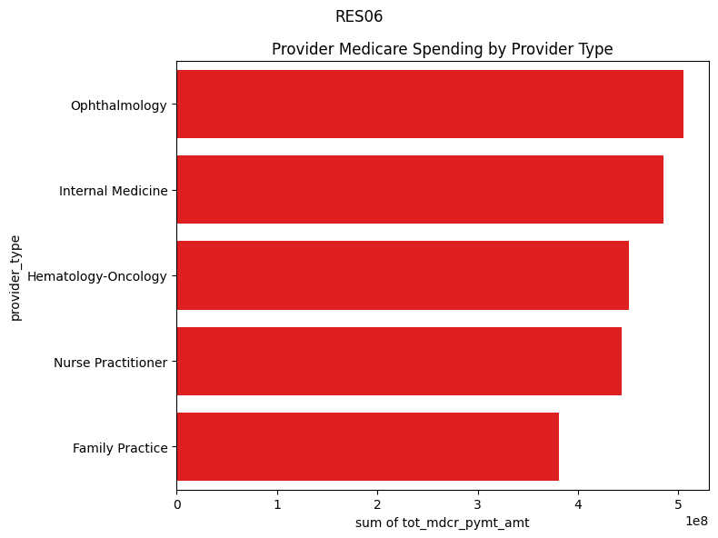

```python
plt.figure(figsize=(8, 6))
sns.barplot(x='tot_mdcr_pymt_amt', y='rndrng_prvdr_type', data=df_res06, color='red')
plt.xlabel('sum of tot_mdcr_pymt_amt')
plt.ylabel('provider_type')
plt.title('Provider Medicare Spending by Provider Type')
plt.suptitle('RES06')
plt.tight_layout()
plt.show()
```

## RES07: TITLE “TOP 10 GENERIC OPIATES BY TOTAL DAY SUPPLY”

```python
res07=prescriptions[prescriptions['is_opiate']=='Yes']
res07=res07.groupby('gnrc_name')['tot_day_suply'].sum().sort_values(ascending=False)
df_res07=res07.reset_index().nlargest(10,'tot_day_suply')
df_res07
```

|  | gnrc_name | tot_day_suply |
| --- | --- | --- |
| 0 | Hydrocodone/Acetaminophen | 43131678 |
| 1 | Oxycodone Hcl/Acetaminophen | 25397036 |
| 2 | Tramadol Hcl | 24085196 |
| 3 | Oxycodone Hcl | 19525172 |
| 4 | Morphine Sulfate | 7015124 |
| 5 | Fentanyl | 2607143 |
| 6 | Methadone Hcl | 1330175 |
| 7 | Acetaminophen With Codeine | 1208236 |
| 8 | Hydromorphone Hcl | 1091654 |
| 9 | Buprenorphine Hcl | 1078222 |

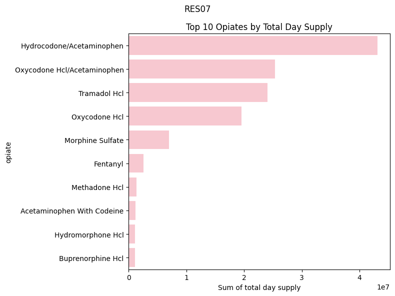

```python
plt.figure(figsize=(8, 6))
sns.barplot(x='tot_day_suply', y='gnrc_name', data=df_res07, color='pink')
plt.xlabel('Sum of total day supply')
plt.ylabel('opiate')
plt.title('Top 10 Opiates by Total Day Supply')
plt.suptitle('RES07')
plt.tight_layout()
plt.show()
```

## RES08: TITLE “TOP 10 MOST EXPENSIVE DRUGS”

```python
prescriptions['claim_cost']=prescriptions['tot_drug_cst']/prescriptions['tot_clms']
```

```python
res08=prescriptions.groupby('brnd_name')['claim_cost'].mean().nlargest(10)
```

```python
df_expensive_drugs= res08.reset_index()
df_expensive_drugs.columns=['brnd_name', 'mean']
df_expensive_drugs
```

|  | brnd_name | mean |
| --- | --- | --- |
| 0 | Myalept | 165046.884167 |
| 1 | Strensiq | 112137.004791 |
| 2 | Berinert | 107622.892727 |
| 3 | Ravicti | 95992.305556 |
| 4 | Firazyr | 75005.836171 |
| 5 | Lumizyme | 73466.830372 |
| 6 | Chenodal | 65809.590000 |
| 7 | Aldurazyme | 63541.299286 |
| 8 | Ayvakit | 61090.000000 |
| 9 | Procysbi | 57488.640638 |

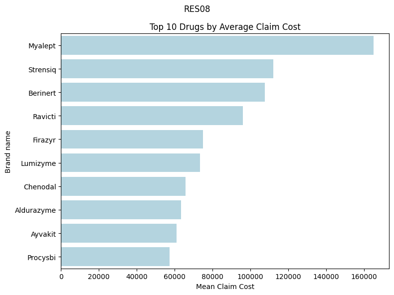

```python
plt.figure(figsize=(8, 6))
sns.barplot(x='mean', y='brnd_name', data=df_expensive_drugs, color= 'lightblue')
plt.xlabel('Mean Claim Cost')
plt.ylabel('Brand name')
plt.title('Top 10 Drugs by Average Claim Cost')
plt.suptitle('RES08')
plt.tight_layout()
plt.show()
```

## RES09: TITLE “TOP 2 CITIES IN SC, NC, TN BY SUM OF TOTAL DAY SUPPLY FOR HYDROCODONE AND OXYCODONE”

```python
#filter prescriptions
res09=prescriptions[prescriptions['gnrc_name'].isin(['Hydrocodone/Acetaminophen', 'Oxycodone Hcl/Acetaminophen'])]
#join with physician_summary
res09=pd.merge(res09, physician_summary, left_on='prscrbr_npi', right_on='rndrng_npi', how='inner')
res09=res09[res09['official_usps_state_code'].isin(['SC','NC','TN'])]
```

```python
#Group by
grouped_res09=res09.groupby(['official_usps_city_name','official_usps_state_code']).agg({
    'tot_day_suply': ['sum', 'mean'],
    'tot_drug_cst': ['sum', 'mean']
}).reset_index()
```

```python
grouped_res09.columns=['city', 'state', 'sum_tot_day_suply', 'mean_tot_day_suply', 'sum_tot_drug_cst', 'mean_drug_cst']
```

```python
#top cities by state
grouped_res09= grouped_res09.sort_values(by=['state', 'sum_tot_day_suply'], ascending=[False, False])
```

```python
top_cities_by_state=grouped_res09.groupby('state').head(2).reset_index()
print(top_cities_by_state)
```

[output not shown]

```python
#state+city palette
top_cities_by_state['state_city']= top_cities_by_state['state'] + " - "+ top_cities_by_state['city']
```

```python
top_cities_by_state
```

|  | index | city | state | sum_tot_day_suply | mean_tot_day_suply | sum_tot_drug_cst | mean_drug_cst | state_city |
| --- | --- | --- | --- | --- | --- | --- | --- | --- |
| 0 | 341 | Knoxville | TN | 1924268 | 1937.832830 | 2268781.57 | 2284.774995 | TN - Knoxville |
| 1 | 102 | Chattanooga | TN | 1690470 | 2493.318584 | 1910374.18 | 2817.661032 | TN - Chattanooga |
| 2 | 617 | Spartanburg | SC | 1418811 | 4247.937126 | 1498101.82 | 4485.334790 | SC - Spartanburg |
| 3 | 214 | Florence | SC | 870433 | 2772.079618 | 1371700.68 | 4368.473503 | SC - Florence |
| 4 | 101 | Charlotte | NC | 1779301 | 1581.600889 | 2149922.08 | 1911.041849 | NC - Charlotte |
| 5 | 536 | Raleigh | NC | 972031 | 1490.845092 | 1660371.08 | 2546.581411 | NC - Raleigh |

```python
my_palette= {
              'TN - Knoxville': 'orange',
              'TN - Chattanooga':'orange',
              'SC - Spartanburg': 'red',
              'SC - Florence': 'red',
              'NC - Charlotte': 'lightblue',
              'NC - Raleigh': 'lightblue',
            }
```

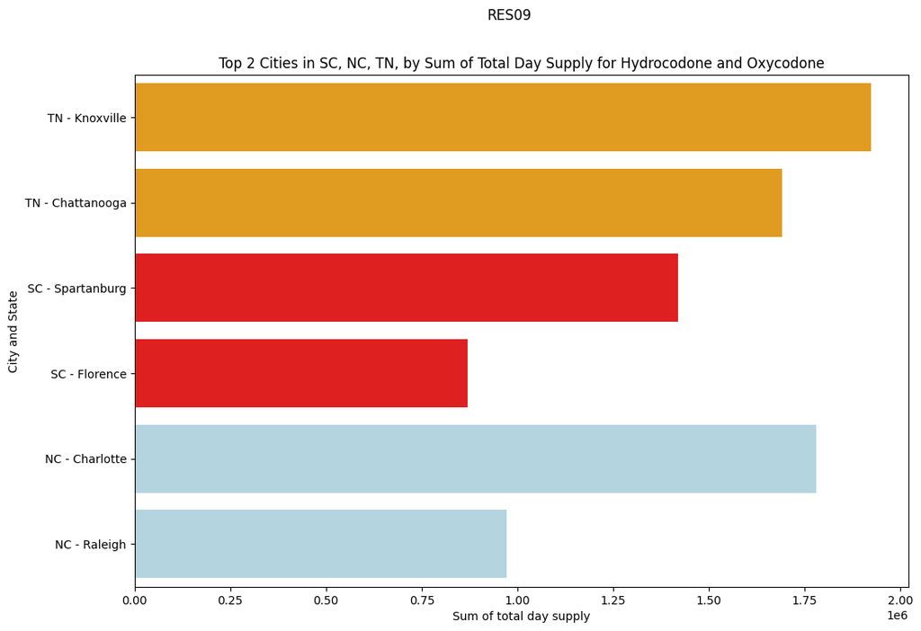

```python
plt.figure(figsize=(12,8))
sns.barplot(data= top_cities_by_state, y='state_city', x='sum_tot_day_suply', palette=my_palette)
plt.xlabel('Sum of total day supply')
plt.ylabel('City and State')
plt.title('Top 2 Cities in SC, NC, TN, by Sum of Total Day Supply for Hydrocodone and Oxycodone')
plt.suptitle('RES09')
plt.show()
```

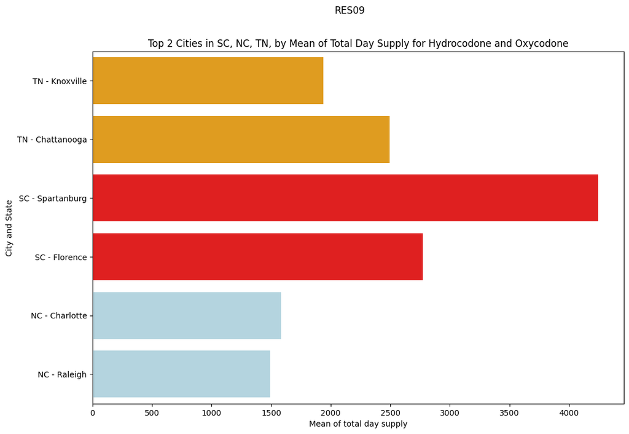

```python
plt.figure(figsize=(12,8))
sns.barplot(data= top_cities_by_state, y='state_city', x='mean_tot_day_suply', palette=my_palette)
plt.xlabel('Mean of total day supply')
plt.ylabel('City and State')
plt.title('Top 2 Cities in SC, NC, TN, by Mean of Total Day Supply for Hydrocodone and Oxycodone')
plt.suptitle('RES09')
plt.show()
```

# RES09 Analysis:

The graphs about show the hydrocodone and oxycodone prescriptions to Medicare patients in our cities of interest. We can observe that Knoxville, TN has the highest total day supply, indicating higher use of these opioids. TN has a high total sum in general which could be because of state laws and demographics. However, when we take the mean of the total day supply, Knoxville is replaced by Spartunburg as the city with the highest mean of total day supply. This is interesting because it shows that the mean is likely affected by outlier bias and doesn't necessarily give a holistic picture of the day supply of the opiods.

For a better analysis, information like demographics, patient age groups, and other prescription drug data can be studied. State laws could also be helpful

## RES10: TITLE "AN OPIATE A DAY"

```python
cities_population = zips[zips["official_usps_state_code"].isin(["TN", "SC", "NC"]) &
                         zips["official_usps_city_name"].isin(["Charlotte", "Chattanooga", "Florence", "Knoxville", "Raleigh", "Spartanburg"])]

cities_population = cities_population.groupby(['official_usps_city_name', 'official_usps_state_code'])['population'].sum().reset_index()
```

```python
res10 = pd.merge(top_cities_by_state, cities_population, left_on=["city", "state"], right_on=["official_usps_city_name", "official_usps_state_code"], how="left")
res10.drop(columns=['official_usps_city_name', 'official_usps_state_code'], inplace=True)
res10['day_suply_per_person'] = res10['sum_tot_day_suply'] / res10['population']
res10
```

|  | index | city | state | sum_tot_day_suply | mean_tot_day_suply | sum_tot_drug_cst | mean_drug_cst | state_city | population | day_suply_per_person |
| --- | --- | --- | --- | --- | --- | --- | --- | --- | --- | --- |
| 0 | 341 | Knoxville | TN | 1924268 | 1937.832830 | 2268781.57 | 2284.774995 | TN - Knoxville | 391360.0 | 4.916874 |
| 1 | 102 | Chattanooga | TN | 1690470 | 2493.318584 | 1910374.18 | 2817.661032 | TN - Chattanooga | 210667.0 | 8.024370 |
| 2 | 617 | Spartanburg | SC | 1418811 | 4247.937126 | 1498101.82 | 4485.334790 | SC - Spartanburg | 112001.0 | 12.667842 |
| 3 | 214 | Florence | SC | 870433 | 2772.079618 | 1371700.68 | 4368.473503 | SC - Florence | 91570.0 | 9.505657 |
| 4 | 101 | Charlotte | NC | 1779301 | 1581.600889 | 2149922.08 | 1911.041849 | NC - Charlotte | 923655.0 | 1.926370 |
| 5 | 536 | Raleigh | NC | 972031 | 1490.845092 | 1660371.08 | 2546.581411 | NC - Raleigh | 555041.0 | 1.751278 |

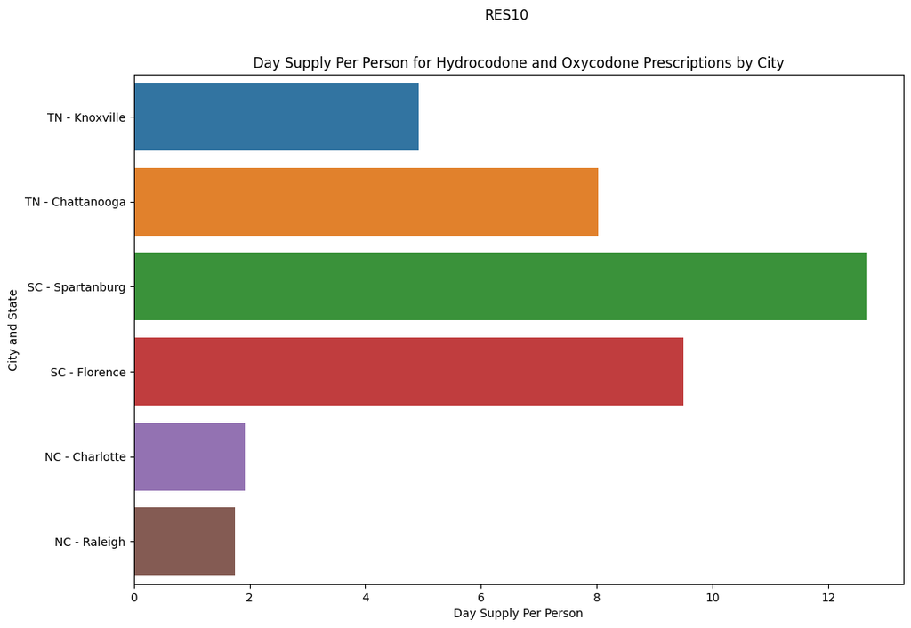

```python
plt.figure(figsize=(12, 8))
sns.barplot(data=res10, y="state_city", x="day_suply_per_person")
plt.xlabel('Day Supply Per Person')
plt.ylabel('City and State')
plt.title('Day Supply Per Person for Hydrocodone and Oxycodone Prescriptions by City')
plt.suptitle('RES10')
plt.show()
```

# RES10 ANALYSIS

The graph shows the day supply of Hydrocodone and Oxycodone (the most most popular opiods) per person. We see that Spartanbug and Florence have a really high daily supply per person which is cause for concern. It could suggest misuse of opiods in the state of South Carolina. To further this analysis, it could be helpful to research the demographics, income, and health status of the people living in those cities. Comparing these results to national and state averages would paint a more holistic picture of the issue

# TASK 4 YOUR ANALYSIS

# RES11: Average Risk Score of Beneficiaries

```python
physician_org_summary=pd.merge(physician_summary, org_summary, how='outer')
```

```python
risk_score_description=physician_org_summary['bene_avg_risk_scre'].describe().reset_index()
risk_score_description
```

|  | index | bene_avg_risk_scre |
| --- | --- | --- |
| 0 | count | 76937.000000 |
| 1 | mean | 1.581725 |
| 2 | std | 0.807129 |
| 3 | min | 0.404100 |
| 4 | 25% | 1.033000 |
| 5 | 50% | 1.340800 |
| 6 | 75% | 1.944200 |
| 7 | max | 11.916900 |

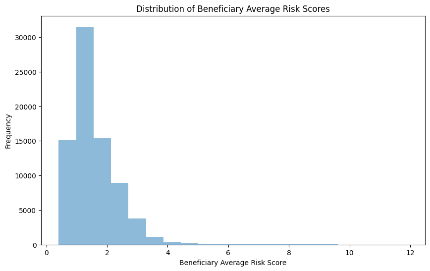

```python
# histogram for 'bene_avg_risk_scre'
plt.figure(figsize=(10, 6))
plt.hist(physician_org_summary['bene_avg_risk_scre'], bins=20, alpha=0.5)
plt.xlabel("Beneficiary Average Risk Score")
plt.ylabel("Frequency")
plt.title("Distribution of Beneficiary Average Risk Scores")
plt.show()
```

# RES12: Top 5 states by Total Submitted Charge and Total Medicare Payment Amount

```python
# Group physician_org_summary by 'official_usps_state_code' and aggregate the sum of 'tot_sbmtd_chrg' and 'tot_mdcr_pymt_amt'
grouped_states = physician_org_summary.groupby('official_usps_state_code').agg({
    'tot_sbmtd_chrg': 'sum',
    'tot_mdcr_pymt_amt': 'sum'
}).reset_index()

# Sort the grouped df by in descending order
top5_states = grouped_states.sort_values(by='tot_sbmtd_chrg', ascending=False).head(5).reset_index()
top5_states
```

|  | index | official_usps_state_code | tot_sbmtd_chrg | tot_mdcr_pymt_amt |
| --- | --- | --- | --- | --- |
| 0 | 3 | NC | 1.171785e+10 | 3.038316e+09 |
| 1 | 7 | TN | 9.262346e+09 | 2.350408e+09 |
| 2 | 6 | SC | 6.552430e+09 | 1.789720e+09 |
| 3 | 8 | TX | 2.632811e+06 | 4.127383e+05 |
| 4 | 4 | NY | 1.077945e+06 | 2.631335e+05 |

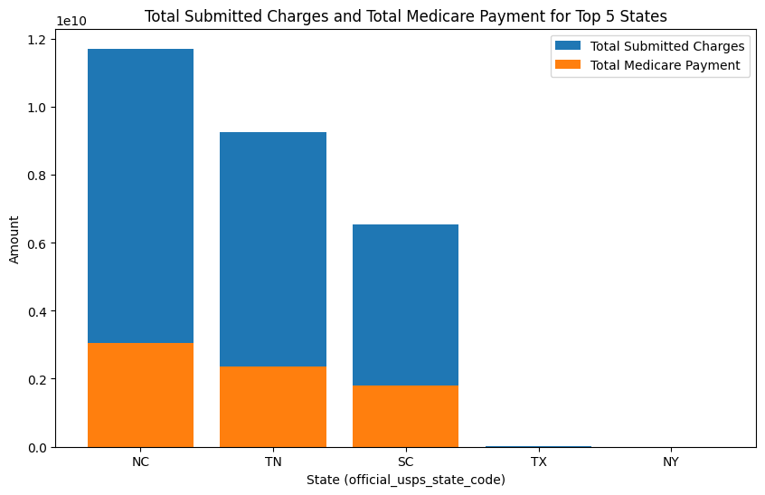

```python
#Bar plot for top 5 states
plt.figure(figsize=(10, 6))
plt.bar(top5_states['official_usps_state_code'], top5_states['tot_sbmtd_chrg'], label='Total Submitted Charges')
plt.bar(top5_states['official_usps_state_code'], top5_states['tot_mdcr_pymt_amt'], label='Total Medicare Payment')
plt.xlabel('State (official_usps_state_code)')
plt.ylabel('Amount')
plt.title('Total Submitted Charges and Total Medicare Payment for Top 5 States')
plt.legend()
plt.show()
```

# RES13: Highest mean total cost of claims by city

```python
#filter prescriptions
res13=prescriptions[prescriptions['gnrc_name'].isin(['Hydrocodone/Acetaminophen'])]
#join with physician_summary
res13=pd.merge(res13, physician_summary, left_on='prscrbr_npi', right_on='rndrng_npi', how='inner')
```

```python
res13.head(2)
```

[output not shown]

2 rows × 103 columns

```python
#multiply total claims for'Hydrocodone/Acetaminophen' with drug cost
res13['total_cost'] = res13['tot_clms'] * res13['tot_drug_cst']
```

```python
# Group by and calculate the mean of 'res13_total cost'
res13_grouped = res13.groupby(['official_usps_city_name', 'official_usps_state_code']).agg(
    total_cost_mean=('total_cost', 'mean')
).reset_index()

# Sort the DataFrame by total cost mean in descending order
res13_grouped = res13_grouped.sort_values(by='total_cost_mean', ascending=False)
res13_grouped['city_state'] = res13_grouped['official_usps_city_name'] + ', ' + res13_grouped['official_usps_state_code']
res13chart=res13_grouped.head(10)
```

```python
res13chart
```

|  | official_usps_city_name | official_usps_state_code | total_cost_mean | city_state |
| --- | --- | --- | --- | --- |
| 608 | Society Hill | SC | 6.650097e+07 | Society Hill, SC |
| 179 | Easley | SC | 2.184093e+07 | Easley, SC |
| 354 | Laurens | SC | 1.983233e+07 | Laurens, SC |
| 537 | Ramer | TN | 1.697627e+07 | Ramer, TN |
| 293 | Honea Path | SC | 1.649819e+07 | Honea Path, SC |
| 478 | North Charleston | SC | 1.633135e+07 | North Charleston, SC |
| 12 | Andrews | NC | 1.489667e+07 | Andrews, NC |
| 640 | Sweetwater | TN | 1.039906e+07 | Sweetwater, TN |
| 73 | Bruceton | TN | 1.013600e+07 | Bruceton, TN |
| 409 | Mauldin | SC | 9.878530e+06 | Mauldin, SC |

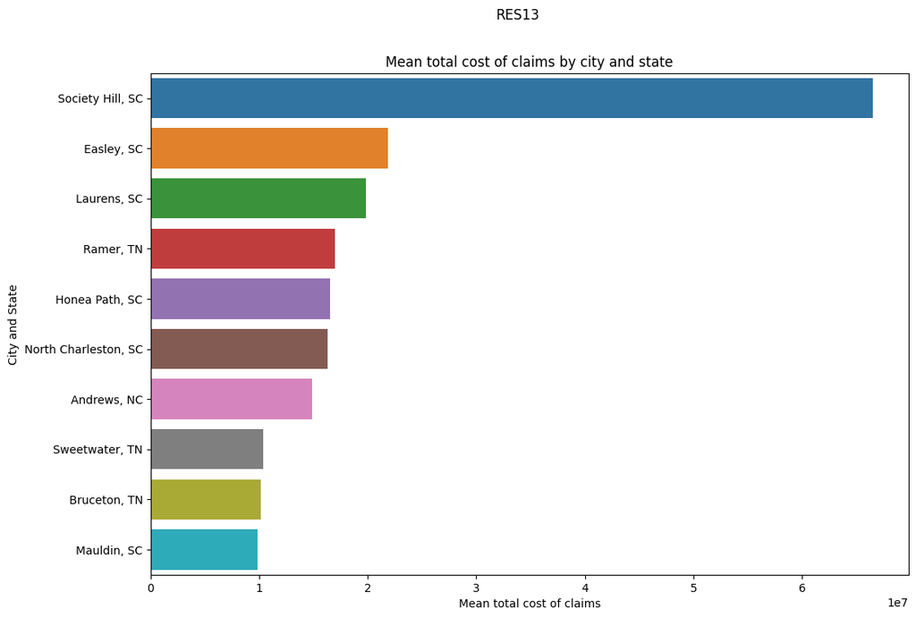

```python
# Bar Chart
plt.figure(figsize=(12, 8))
sns.barplot(data=res13chart, y="city_state", x="total_cost_mean")
plt.xlabel('Mean total cost of claims')
plt.ylabel('City and State')
plt.title('Mean total cost of claims by city and state')
plt.suptitle('RES13')
plt.show()
```

# RES14: Hydrocodone-Acetaminophen Beneficiaries by Gender

```python
# Merge 'physician_summary' and 'prescriptions'
res14_df = physician_summary.merge(prescriptions, left_on='rndrng_npi', right_on='prscrbr_npi')
res14_df.shape
```

```
(1725689, 102)
```

```python
# Filter the df for 'Hydrocodone-Acetaminophen'
res14_filtered = res14_df[res14_df['brnd_name'] == 'Hydrocodone-Acetaminophen']
```

```python
#gender columns
ha_drug_age = ['bene_feml_cnt', 'bene_male_cnt']
ha_drug_age_filtered = res14_filtered[ha_drug_age]
ha_drug_age_filtered
```

|  | bene_feml_cnt | bene_male_cnt |
| --- | --- | --- |
| 142 | 122.0 | 98.0 |
| 258 | 71.0 | 38.0 |
| 320 | 74.0 | 66.0 |
| 434 | 83.0 | 130.0 |
| 552 | 310.0 | 267.0 |
| ... | ... | ... |
| 1725288 | 76.0 | 66.0 |
| 1725469 | 144.0 | 79.0 |
| 1725553 | 134.0 | 92.0 |
| 1725631 | NaN | NaN |
| 1725681 | 397.0 | 307.0 |

17327 rows × 2 columns

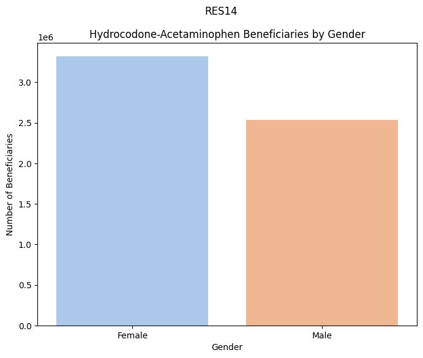

```python
#graph
gender_labels = ['Female', 'Male']
female_counts = ha_drug_age_filtered['bene_feml_cnt']
male_counts = ha_drug_age_filtered['bene_male_cnt']

gender_data = pd.DataFrame({'Gender': ['Female', 'Male'],
                            'Count': [female_counts.sum(), male_counts.sum()]})

plt.figure(figsize=(8, 6))
sns.barplot(data=gender_data, x='Gender', y='Count', palette='pastel')
plt.suptitle('RES14')
plt.xlabel('Gender')
plt.ylabel('Number of Beneficiaries')
plt.title('Hydrocodone-Acetaminophen Beneficiaries by Gender')
plt.show()
```

# RES15: Average Age of Beneficiaries

```python
avg_age=physician_org_summary['bene_avg_age'].describe().reset_index()
avg_age
```

|  | index | bene_avg_age |
| --- | --- | --- |
| 0 | count | 76937.000000 |
| 1 | mean | 71.154074 |
| 2 | std | 5.162025 |
| 3 | min | 11.000000 |
| 4 | 25% | 70.000000 |
| 5 | 50% | 72.000000 |
| 6 | 75% | 74.000000 |
| 7 | max | 91.000000 |

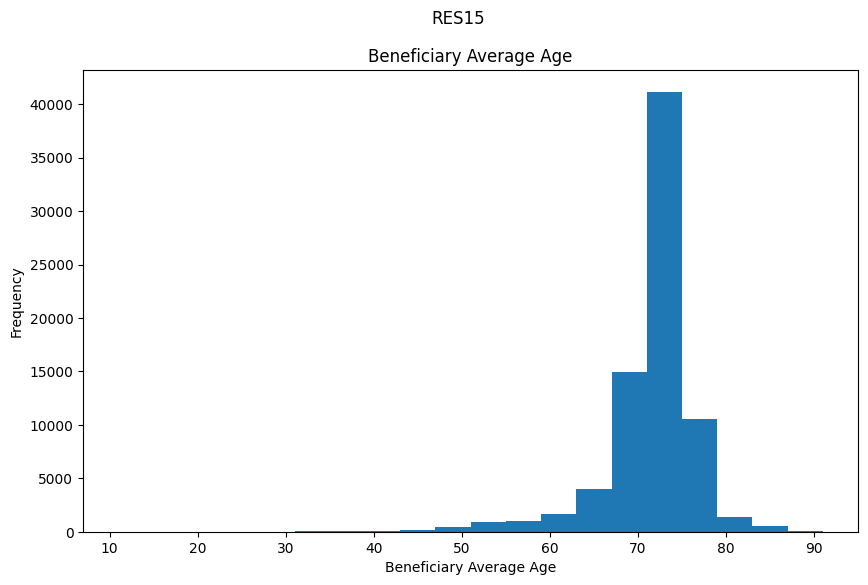

```python
# histogram for 'bene_avg_age'
plt.figure(figsize=(10, 6))
plt.hist(physician_org_summary['bene_avg_age'], bins=20)
plt.xlabel("Beneficiary Average Age")
plt.ylabel("Frequency")
plt.title("Beneficiary Average Age")
plt.suptitle('RES15')
plt.show()
```